# Restoration in Cauca Valley Watersheds

Tim Meehan

2024-03-13

## Question

Can we make forested areas in the Cauca Valley more bird friendly through restoration? First let’s look at baseline BFI values across possible restoration sites and see if it can be related to current land cover.

## Set up analysis

First, we load a bunch of libraries and set some options.

```r
# set up
library(cluster)
library(NbClust)
library(vegan)
library(unmarked)
library(mgcv)
library(mgcViz)
library(tidyverse)
library(lubridate)
library(stringr)

setwd("C:/Users/tmeehan/Box/Cauca Valley monitoring/r_work")

options(scipen=99999)
options(max.print=99999)
options(stringsAsFactors=F)
```

## Get data

Next, we get the count data, remove flyover birds, add a month column, and change Spanish words to English for the gringos on staff. We then select only landbird species and only those with trait data for functional species assignment. We end up analyzing data for 225 species.

The species table that is imported at the end of this code block is a critical input to the analysis as it has species detection scores derived from professional opinion, species conservation scores from Partners in Flight, and a bunch of traits related to food type, foraging stratum, and body size for functional species determination.

```r
# get raw count data
d0 <- read.csv("count_data.csv") %>%
  rename_all(tolower) %>%
  rename_all(~ gsub(".", "_", ., fixed=T)) %>%
  filter(tipo_de_registro %in% c("Visual","Auditivo","visual","auditivo")) %>%
  mutate(distance=as.numeric(stringr::str_trim(distancia))) %>%
  mutate(date=dmy(paste0(str_trim(fecha), "-2023"))) %>%
  mutate(hora_inicio=hm(hora_inicio),
         hora_final=hm(hora_final)) %>%
  mutate(start_time=hour(hora_inicio)+(minute(hora_inicio)/60),
         end_time=hour(hora_final)+(minute(hora_final)/60),
         month=month(date)) %>%
  mutate(count=as.numeric(str_trim(individuos)),
         observador=str_trim(observador),
         cuenca=str_trim(cuenca),
         celda=str_trim(celda),
         punto=str_trim(punto)) %>%
  filter(!is.na(count)) %>%
  select(watershed=cuenca, site=celda, point=punto, date, month,
         observer_id=observador, start_time, end_time, species=especie,
         distance, count) %>%
  uncount(count) %>%
  mutate(month=ifelse(month==9, 8, month))

# just landbird species with trait data
spp1 <- read.csv("species_data.csv") %>%
  filter(guild=="landbird")
d1 <- d0 %>% filter(species %in% spp1$species)
```

## Distance analysis

Next, we take advantage of the distance data collected and calculate distance based detection probabilities per species. First, we trim the observations to 80 m to capture the data most informative for distance analysis. Then we restrict the data to species with at least 20 observations. Then, for each species, site, point, and month, we count the number of individuals per 4 distance bins. Then we zero fill the bins. Then we loop through the species and calculate species-specific distance functions and detection probabilities. The histogram at the bottom shows the variation across species in distance-based detection probabilities within 80 m of an observer.

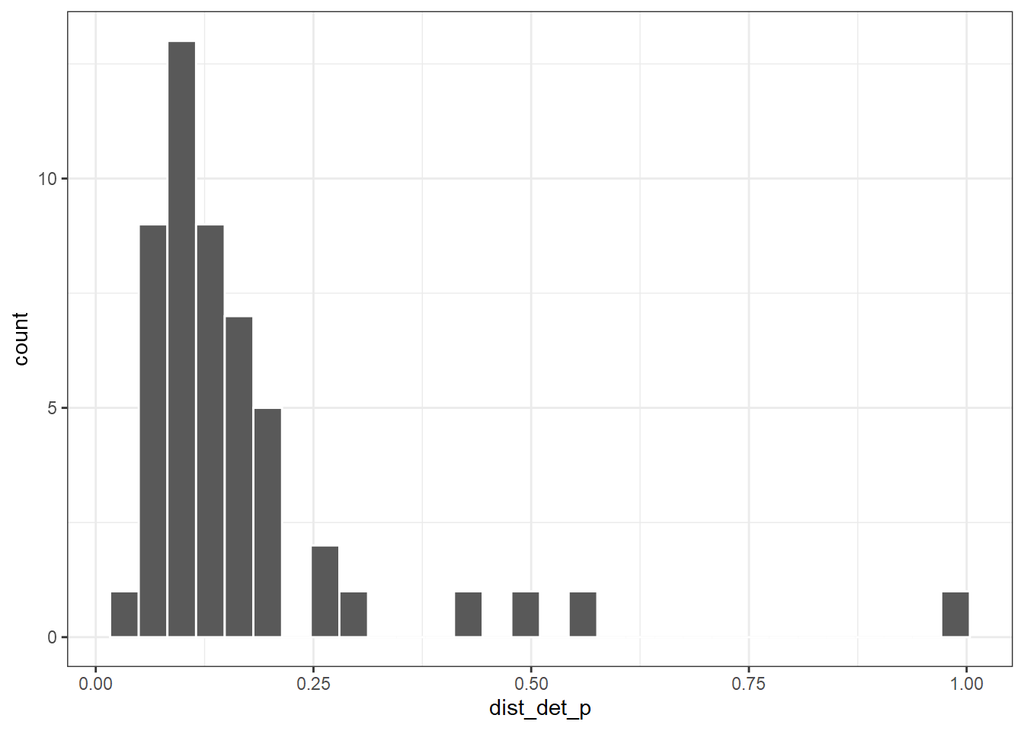

```r
# filter out no distance data and distance over 80 m
max_d <- 80
d2 <- d1 %>%
  filter(!is.na(distance),
         distance<=max_d)

# just species with large sample more than 20
thresh_ss <- 20
d2 <- d2 %>% group_by(species) %>% mutate(n_counted=n()) %>%
  ungroup() %>%
  filter(n_counted>=thresh_ss) %>%
  arrange(species)

# info
n_species <- length(unique(d2$species))
spp_nams <- unique(d2$species)

# make counts per bin
d3 <- d2 %>%
  mutate(distance_bin=ifelse(distance<max_d/4, max_d/4, ifelse(
    distance>=max_d/4 & distance<max_d/2, max_d/2, ifelse(
      distance>=max_d/2 & distance<max_d*3/4, max_d*3/4, max_d)))) %>%
  group_by(site, point, month, species, distance_bin) %>%
  count()

# zero fill
all_combos <- expand_grid(site=unique(d3$site),
                          point=unique(d3$point),
                          month=unique(d3$month),
                          species=unique(d3$species),
                          distance_bin=unique(d3$distance_bin))
d4 <- all_combos %>% left_join(d3) %>% mutate(n=ifelse(is.na(n), 0, n)) %>%
  arrange(distance_bin, species, n)

# loop through species
dist_out <- c()
for(i in 1:length(spp_nams)){
  # data
  d_i <- d4 %>% filter(species==spp_nams[i]) %>%
    pivot_wider(values_from=n, names_from=distance_bin)
  # umf
  umf_i <- unmarkedFrameDS(y=as.matrix(d_i[,5:8]),
                            #siteCovs=data.frame(),
                            dist.breaks=c(0,max_d/4,max_d/2,max_d*3/4, max_d),
                            unitsIn="m", survey="point")
  # model
  dm_i <- distsamp(~1 ~1, umf_i)
  # effective area
  sig <- exp(coef(dm_i, type="det"))
  ea <- 2*pi * integrate(grhn, 0, max_d, sigma=sig)$value
  # detection probability
  dp_i <- ea / (pi*max_d^2)
  df_i <- data.frame(species=spp_nams[i], dist_det_p=dp_i)
  dist_out <- rbind(dist_out, df_i)
}

# show histogram of detection
ggplot(dist_out) + geom_histogram(aes(x=dist_det_p), col="white") +
  theme_bw()
```

## Occupancy analysis

Next, we take advantage of repeat observations by two observers and calculate occupancy based detection probabilities. Again, this analysis is for species where there are at least 20 observations. The histogram at the bottom shows the variation across species in occupancy-based detection probabilities.

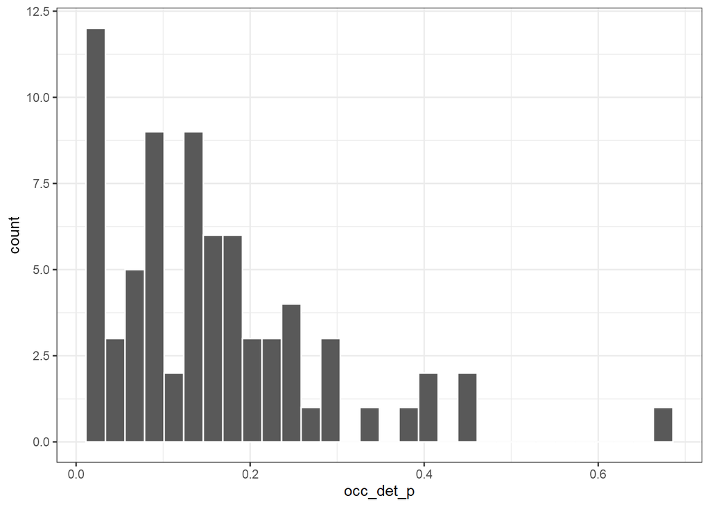

```r
# just species with large sample more than 20
d2 <- d1 %>% group_by(species) %>% mutate(n_counted=n()) %>%
  ungroup() %>%
  filter(n_counted>=thresh_ss) %>%
  arrange(species)

# info
n_species <- length(unique(d2$species))
spp_nams <- unique(d2$species)

# make counts
d3 <- d2 %>%
  mutate(observer_id=str_trim(observer_id)) %>%
  group_by(site, point, month, species, observer_id) %>%
  count()

# zero fill
all_combos <- expand_grid(site=unique(d3$site),
                          point=unique(d3$point),
                          month=unique(d3$month),
                          species=unique(d3$species),
                          observer_id=unique(d3$observer_id))
d4 <- all_combos %>% left_join(d3) %>%
  mutate(n=ifelse(is.na(n), 0, n)) %>%
  arrange(site, point, month, species) %>%
  pivot_wider(values_from = n, names_from=observer_id) %>%
  rename(y1=SANTIAGO, y2=JUAN) %>%
  arrange(species, site, point, month) %>%
  mutate(y2=ifelse(y2>0, 1, 0),
         y1=ifelse(y1>0, 1, 0))

# loop through species
occ_out <- c()
for(i in 1:length(spp_nams)){
  d_i <- d4 %>% filter(species==spp_nams[i]) %>% select(y1, y2) %>% as.matrix()
  umf_i <- unmarkedFrameOccu(y=d_i)
  om_i <- occu(~1 ~1, umf_i)
  p_i <- as.numeric(plogis(coef(om_i)[2]))
  df_i <- data.frame(species=spp_nams[i],
                      occ_det_p=p_i)
  occ_out <- rbind(occ_out, df_i)
}

# show histogram of detection
ggplot(occ_out) + geom_histogram(aes(x=occ_det_p), col="white") + theme_bw()
```

## Detection scores

Now we have distance based and occupancy based detection probabilities for a subset of the 225 species. We use the detection scores from the species table to apply these modeled detection probabilities to species where there were not enough observations to build a model. This is done by applying the group mean detection probability per 3 detection scores to unmodeled species based on their own detection score. Note that detection scores 1, 2, and 3 coincide with average detection probabilities of 0.10, 0.17, and 0.17 for distance analysis and 0.11, 0.13, and 0.18 for occupancy analysis.

```r
# combine and distribute detection probabilities
detect_scores <- spp1 %>% select(species, com_name=Clements_2023_com_name,
                                detect_score=detectability_score) %>%
  left_join(dist_out) %>% left_join(occ_out)

# get distance detection probability means per score
(dist_mean_coefs <- coef(lm(dist_det_p~-1+factor(detect_score),
                            data=detect_scores)))
```

```
#> factor(detect_score)1 factor(detect_score)2 factor(detect_score)3
#>             0.1037586             0.1737298             0.1712454
```

```r
# get occupancy detection probability means per score
(occ_mean_coefs <- coef(lm(occ_det_p~-1+factor(detect_score),
                           data=detect_scores)))
```

```
#> factor(detect_score)1 factor(detect_score)2 factor(detect_score)3
#>             0.1130082             0.1282066             0.1801460
```

```r
# distribute estimates to NA values
detect_scores <- detect_scores %>%
  mutate(dist_det_p=ifelse(is.na(dist_det_p) & detect_score==1,
                           dist_mean_coefs[1],
                           ifelse(is.na(dist_det_p) & detect_score==2,
                                  dist_mean_coefs[2],
                                  ifelse(is.na(dist_det_p) &
                                           detect_score==3,
                                         dist_mean_coefs[3], dist_det_p)))) %>%
  mutate(occ_det_p=ifelse(is.na(occ_det_p) & detect_score==1,
                           occ_mean_coefs[1],
                           ifelse(is.na(occ_det_p) & detect_score==2,
                                  occ_mean_coefs[2],
                                  ifelse(is.na(occ_det_p) &
                                           detect_score==3,
                                         occ_mean_coefs[3], occ_det_p))))
```

## Make functional species

Next we group species into functional species based on ecological traits. This is done by making a Gower dissimilarity matrix from the traits data. When making the dissimilarity matrix, traits are weighted equally for diet composition, foraging stratum and body size. Then we use the dissimilarity matrix in a hierarchical cluster analysis that produces a functional species tree. The optimal number of tree clusters can be determined using a fit metric such as the silhouette width. We end up with 13 functional species in these communities.

```r
# functional data for clustering
t1 <- spp1 %>% filter(guild=="landbird") %>%
  rename_with(~tolower(gsub(".", "_", .x, fixed=T))) %>%
  select(-(2:7))

# make a distance matrix
d_gower <- daisy(t1[,-1], metric="gower", stand=TRUE,
                 weights=c(rep(3/9/10, 10),
                           rep(3/9/8, 8),
                           rep(3/9/1, 1)))
# create clusters
clust <- NbClust(diss=d_gower, distance=NULL, method="ward.D",
                 index="silhouette")
```

```
#>
#>  Only frey, mcclain, cindex, sihouette and dunn can be computed. To compute the other indices, data matrix is needed
```

```r
clust$Best.nc
```

```
#> Number_clusters     Value_Index
#>         13.0000          0.2685
```

```r
# best clusters
func_out <-  spp1 %>% filter(guild=="landbird") %>%
  select(species, com_name=Clements_2023_com_name) %>%
  mutate(func_spec=clust$Best.partition) %>%
  arrange(func_spec)
```

## Conservation scores

Then we grab conservation scores per species from the species table and combine the species IDs, detection probabilities, functional species IDs, and conservation scores into a new species table. Then we join this species level data with the count data and adjust counts based on detection probability. We are skeptical about the use of the occupancy based probabilities given only two repeat measures and given the ecological characteristics of tropical species (e.g., movement through large territories). So we go with the distance based detection corrections and ignore those from occupancy analysis.

```r
# get conservation scores
cscore_out <- spp1 %>% filter(guild=="landbird") %>%
  rename_with(~tolower(gsub(".", "_", .x, fixed=T))) %>%
  select(species, ccs_b)

# combine all species level info
final_spp_tab <- detect_scores %>%
  left_join(func_out %>% select(-2)) %>%
  left_join(cscore_out)
write_csv(final_spp_tab, "final_species_table_030824.csv")

# combine counts and species level data
d5 <- d1 %>%
  filter(distance<=max_d) %>%
  group_by(watershed, site, point, month, observer_id, species) %>%
  count() %>%
  ungroup %>%
  group_by(watershed, site, point, month, species) %>%
  summarise(mean_count=mean(n)) %>%
  ungroup() %>%
  left_join(final_spp_tab) %>%
  mutate(occ_correct_mean_count=mean_count*(1/occ_det_p)) %>% # occupancy adjust
  mutate(detect_correct_mean_density=(mean_count*(1/dist_det_p))*
           (pi*max_d*max_d/(100*100))) %>% # distance adjust
  mutate(score_weighted_dens=detect_correct_mean_density*ccs_b)
```

## Calculate BFI

Now we calculate BFI components and BFI per site, point, and month. One component is the sum of the products of the detection-corrected species counts and conservation scores. A second component is the Shannon diversity of functional groups. Once the components are computed, total BFI is calculated and scaled so that the range is 0 to 1 and 0.5 represents an average value.

```r
# point level bfi and other metrics
point_bfi <- d5 %>% group_by(watershed, site, point, month) %>%
  summarize(spp_rich=n(),
            func_rich=length(unique(func_spec)),
            func_shannon=diversity(detect_correct_mean_density),
            sum_cw_abund=sum(score_weighted_dens)) %>%
  ungroup() %>%
  mutate(bfi_unscaled=func_shannon*sum_cw_abund,
         bfi_scaled=plogis(as.numeric(scale(bfi_unscaled))))
```

## Habitat data

Once we have BFI per site, point, and month, we grab the habitat data associated with each site and point and merge the that with BFI values. We plot it for fun.

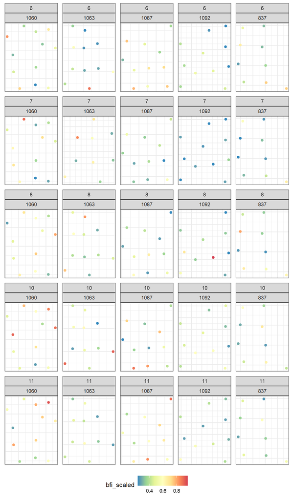

```r
# join bfi with habitat
h1 <- read_csv("habitat_data.csv") %>%
  mutate(site_point=str_trim(site_point),
         site=str_split(site_point, pattern="-", simplify = T)[,1],
         point=str_split(site_point, pattern="-", simplify = T)[,2]) %>%
  select(-site_point) %>%
  select(watershed, site, point, x, y, starts_with("perc")) %>%
  arrange(site, point)
point_bfi_habitat <- point_bfi %>% left_join(h1) %>%
  mutate(watershed=factor(watershed),
         site=factor(site),
         point=factor(point),
         month=factor(month))

# map it
point_bfi_habitat %>% filter(watershed=="Guacaica") %>%
  ggplot() +
  geom_point(aes(x=x, y=y, color=bfi_scaled)) +
  scale_color_distiller(palette="Spectral") +
  facet_wrap(vars(month, site), scales="free", nrow=5) +
  theme_bw() +
  theme(legend.position = "bottom",
        axis.title=element_blank(),
        axis.text=element_blank(),
        axis.ticks=element_blank())
```

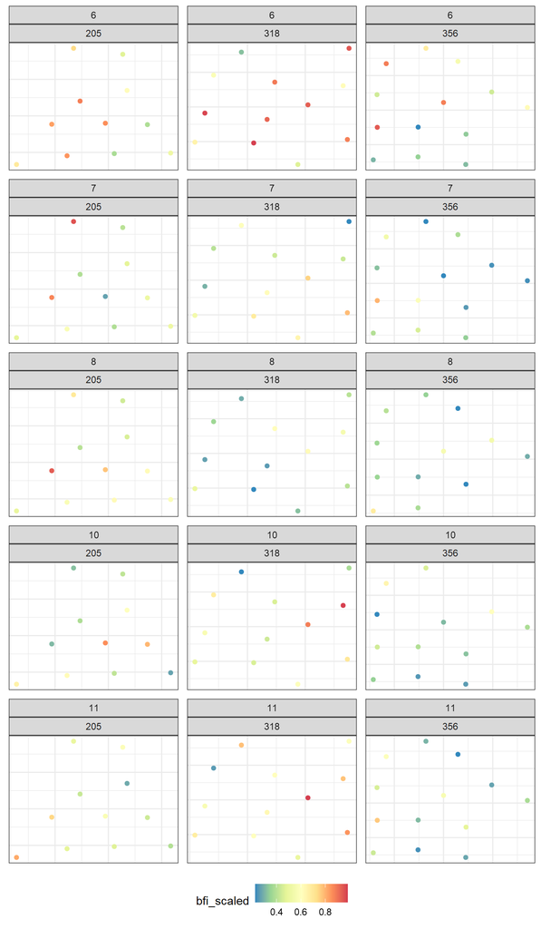

```r
point_bfi_habitat %>% filter(watershed!="Guacaica") %>%
  ggplot() +
  geom_point(aes(x=x, y=y, color=bfi_scaled)) +
  scale_color_distiller(palette="Spectral") +
  facet_wrap(vars(month, site), scales="free", nrow=5) +
  theme_bw() +
  theme(legend.position = "bottom",
        axis.title=element_blank(),
        axis.text=element_blank(),
        axis.ticks=element_blank())
```

## BFI model

```r
# quick model
mod1 <- gam(bfi_scaled ~ 1 + site + month +
              s(perc_forest_no_fence, k=3) +
              s(perc_savanna, k=3) +
              s(perc_pasture, k=3) +
              s(perc_water, k=3),
            data=point_bfi_habitat)

# model summary
summary(mod1)
```

```
#>
#> Family: gaussian
#> Link function: identity
#>
#> Formula:
#> bfi_scaled ~ 1 + site + month + s(perc_forest_no_fence, k = 3) +
#>     s(perc_savanna, k = 3) + s(perc_pasture, k = 3) + s(perc_water,
#>     k = 3)
#>
#> Parametric coefficients:
#>             Estimate Std. Error t value             Pr(>|t|)
#> (Intercept)  0.56712    0.02992  18.955 < 0.0000000000000002 ***
#> site1063    -0.05480    0.03634  -1.508             0.132321
#> site1087    -0.01867    0.03667  -0.509             0.610991
#> site1092    -0.12465    0.03746  -3.328             0.000952 ***
#> site205      0.05549    0.03541   1.567             0.117821
#> site318      0.05482    0.03681   1.489             0.137200
#> site356     -0.08175    0.03530  -2.316             0.021031 *
#> site837     -0.10381    0.03824  -2.715             0.006902 **
#> month7      -0.10266    0.02716  -3.779             0.000179 ***
#> month8      -0.07296    0.02716  -2.686             0.007505 **
#> month10     -0.03434    0.02708  -1.268             0.205506
#> month11     -0.03127    0.02700  -1.158             0.247451
#> ---
#> Signif. codes:  0 '***' 0.001 '**' 0.01 '*' 0.05 '.' 0.1 ' ' 1
#>
#> Approximate significance of smooth terms:
#>                           edf Ref.df     F p-value
#> s(perc_forest_no_fence) 1.000  1.000 9.821 0.00184 **
#> s(perc_savanna)         1.000  1.000 1.173 0.27939
#> s(perc_pasture)         1.775  1.949 3.352 0.06331 .
#> s(perc_water)           1.877  1.985 4.694 0.01373 *
#> ---
#> Signif. codes:  0 '***' 0.001 '**' 0.01 '*' 0.05 '.' 0.1 ' ' 1
#>
#> R-sq.(adj) =  0.176   Deviance explained = 20.7%
#> GCV = 0.034166  Scale est. = 0.032811  n = 445
```

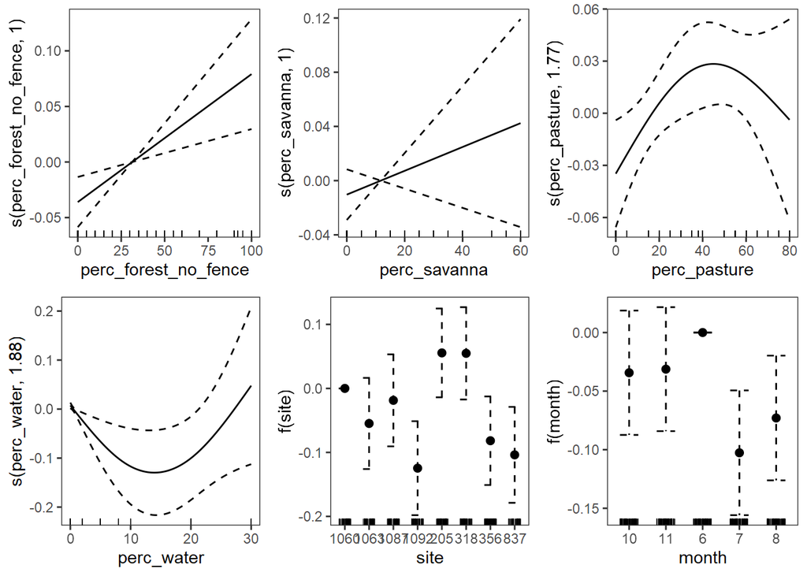

```r
# plot effects
b <- getViz(mod1)
print(plot(b, allTerms = T), pages = 1)
```

## Treatment effects

Next we look to see if there are any systematic differences between the control and treatment sites in terms of BFI and find that there are none.

```r
treat1 <- read.csv("site_treatment.csv") %>% distinct() %>%
  mutate_all(as.factor)
bfi_hab_treat <- point_bfi_habitat %>% left_join(treat1, by="site")

# quick model
mod1 <- gam(bfi_scaled ~ 1 +
              s(site, bs="re") +
              s(watershed, bs="re") +
              s(month, bs="re") +
              treatment,
            data=bfi_hab_treat)

# model summary
summary(mod1)
```

```
#>
#> Family: gaussian
#> Link function: identity
#>
#> Formula:
#> bfi_scaled ~ 1 + s(site, bs = "re") + s(watershed, bs = "re") +
#>     s(month, bs = "re") + treatment
#>
#> Parametric coefficients:
#>                    Estimate Std. Error t value            Pr(>|t|)
#> (Intercept)         0.49755    0.06106   8.149 0.00000000000000395 ***
#> treatmentTreatment -0.01532    0.06691  -0.229               0.819
#> ---
#> Signif. codes:  0 '***' 0.001 '**' 0.01 '*' 0.05 '.' 0.1 ' ' 1
#>
#> Approximate significance of smooth terms:
#>                 edf Ref.df      F  p-value
#> s(site)      5.3348      6 10.997 0.000146 ***
#> s(watershed) 0.1226      1  1.947 0.315711
#> s(month)     3.0361      4  3.139 0.002712 **
#> ---
#> Signif. codes:  0 '***' 0.001 '**' 0.01 '*' 0.05 '.' 0.1 ' ' 1
#>
#> R-sq.(adj) =   0.14   Deviance explained = 15.9%
#> GCV = 0.035049  Scale est. = 0.034222  n = 445
```

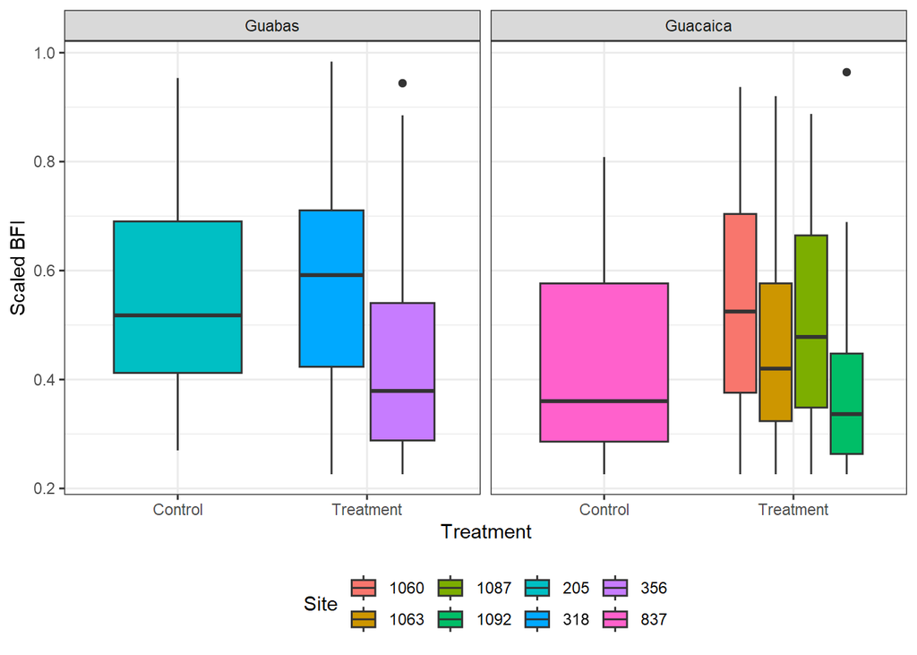

```r
# plot per treatment and site
ggplot(bfi_hab_treat, aes(x=treatment, y=bfi_scaled, fill=site)) +
  geom_boxplot() +
  facet_wrap(~watershed) +
  scale_color_brewer(palette="Dark2") +
  labs(x="Treatment", y="Scaled BFI", fill="Site") +
  theme_bw() +
  theme(legend.position = "bottom")
```

## Conclusion

This is the first pass of the analysis. Please let Tim Meehan know what you would like added or taken away. Or you can take it from here. If there is anything at all that is not clear in this document. Please do not hestitate to contact Tim Meehan at tmeehan@audubon.org